# Peltsi

Mallin validointia… Vaatisi vähän syventymistä aiheeseen..

```r
summary(G2)
```

```
##
## Family: Tweedie(p=1.149)
## Link function: log
##
## Formula:
## terriD ~ year + agri5 + Abuild + Astream + Aroad + Ariver + s(Y) +
##     s(X) + s(fyear, bs = "re") + s(id, bs = "re")
##
## Parametric coefficients:
##              Estimate Std. Error t value Pr(>|t|)
## (Intercept)  1.065579   0.077853  13.687  < 2e-16 ***
## year        -0.436105   0.070760  -6.163 9.58e-10 ***
## agri5        0.258158   0.062373   4.139 3.72e-05 ***
## Abuild       0.008376   0.068149   0.123    0.902
## Astream      0.039367   0.053370   0.738    0.461
## Aroad       -0.017071   0.063012  -0.271    0.786
## Ariver       0.202266   0.048760   4.148 3.58e-05 ***
## ---
## Signif. codes:  0 '***' 0.001 '**' 0.01 '*' 0.05 '.' 0.1 ' ' 1
##
## Approximate significance of smooth terms:
##              edf  Ref.df      F  p-value
## s(Y)       4.957   5.259 13.662 2.10e-13 ***
## s(X)       5.287   5.644  9.433 1.50e-09 ***
## s(fyear)  12.411  17.000  6.163 5.36e-14 ***
## s(id)    185.445 274.000  2.289  < 2e-16 ***
## ---
## Signif. codes:  0 '***' 0.001 '**' 0.01 '*' 0.05 '.' 0.1 ' ' 1
##
## R-sq.(adj) =  0.538   Deviance explained = 50.6%
## -REML = 3105.3  Scale est. = 2.2529    n = 1474
```

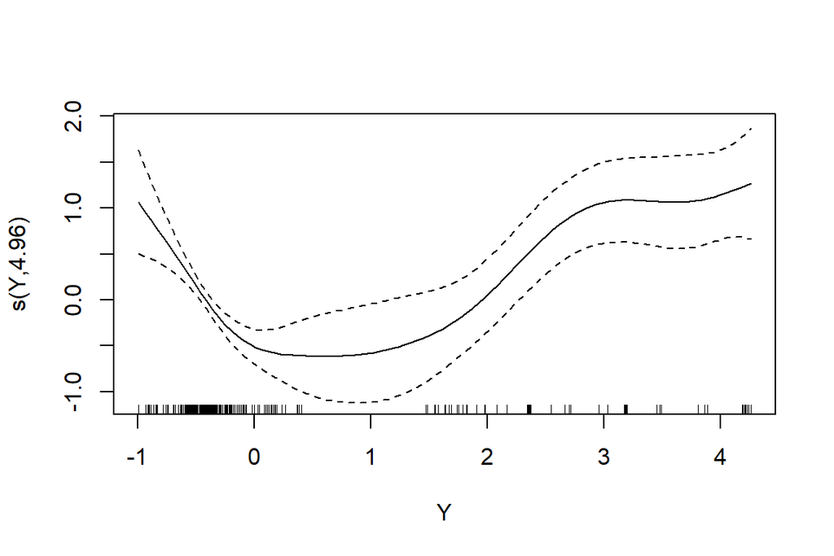

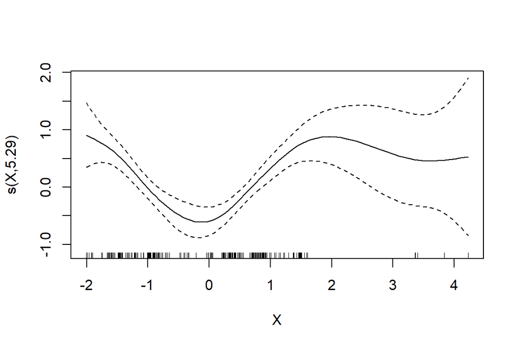

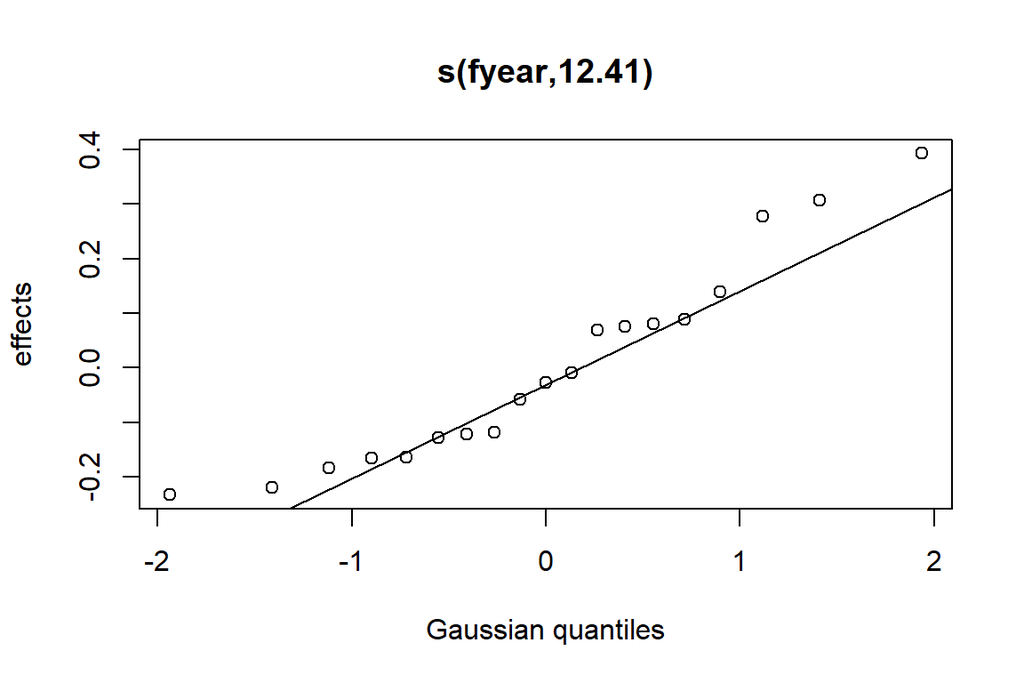

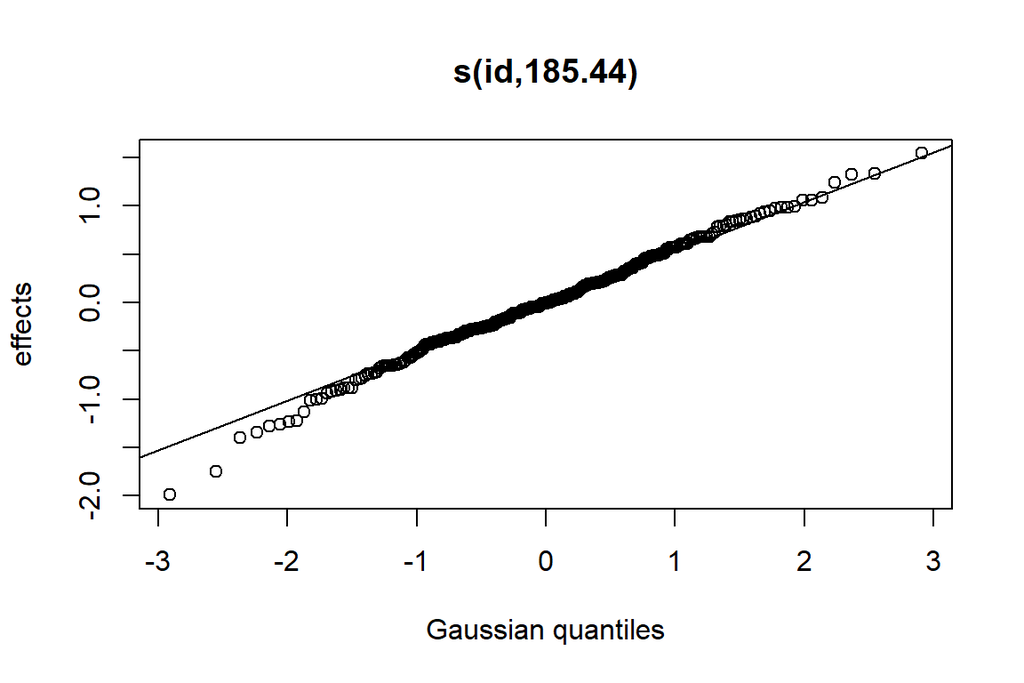

```r
plot(G2)
```

```r
G2$gam
```

GAM-mallien validointi ja visualisointi on vielä vähän hakusessa. Residuaalit pitäisi tässäkin tarkistaa.

### 2.2.4 GAM, NB, offset, (0 + vuosi|lauluryhmä)

Perus-GAM, jossa random-rakenne on smootherina. Selitettävänä muuttujana reviirien määrä. Pinta-ala offsettina. Negative binomial jakauma.

Mutta [tässä](http://martijnwieling.nl/files/GAM-tutorial-Wieling.pdf) tutoriaalissa sanotaan ettei random slopen ja random interceptin välille ole mahdollista ohjelmoida gam-funktiolla korrelaatiota:

*Including a random slope* In similar fashion, we may include a by-speaker linear random slope (which would correspond to tilting the non-linear pattern) for the two-word-contrast (Word) as follows:

m4 <- bam(Pos ~ Word + s(Time, by=Word) + s(Speaker,bs=“re”) + s(Speaker,Word,bs=“re”), data=dat)

In the lmer specification this random slope would be represented by **(0+Word|Speaker)**. Unfortunately, in the GAM specification, it is not possible to model a correlation between random intercepts and random slopes (i.e. an lmer specification such as (1+Word|Speaker) is not possible). At present this is a drawback compared to linear mixed-effects regression, at least when linear random slopes are used.

Eli alla käyttämäni random-rakenne ei ole oikein, tai ainakaan just se mitä haetaan. Random slopen ja random interceptin välille ei saa korrelaatiota. Pitäisi kai käyttää GAMM-funktiota sit kuitenkin.

```r
M1 <- gam(terri ~ year + s(id, bs="re") + s(year,id, bs ="re"), offset=log(area), family = nb(), data= dataS, method = "ML")

M2 <- gam(terri ~ Abuild + Astream + Aroad + Ariver + agri5*year + s(Y, bs ="cs") + s(X, bs ="cs") + s(id, bs="re") + s(year,id, bs="re"), offset=log(area), family = nb(),data= dataS, method = "ML")

M3 <- gam(terri ~ Abuild + Astream + Aroad + Ariver + agri5*year + s(Y, bs ="cs") + s(X, bs ="cs") + year*temp + year*prec + s(id, bs="re") + s(year,id, bs="re"), offset=log(area), family = nb(), data= dataS, method = "ML")

M4 <- gam(terri ~ Abuild + Astream + Aroad + Ariver + agri5*year + s(Y, bs ="cs") + s(X, bs ="cs") + year*shanG + year*open + s(id, bs="re") + s(year,id, bs="re"), offset=log(area), family = nb(), data= dataS, method = "ML")

M5 <- gam(terri ~ Abuild + Astream + Aroad + Ariver + agri5*year + s(Y, bs ="cs") + s(X, bs ="cs") + year*temp + year*prec + year*shanG + year*open + s(id, bs="re") + s(year,id, bs="re"), offset=log(area), family = nb(), data= dataS, method = "ML")

AIC(M1,M2,M3,M4,M5)
```

```
##          df      AIC
## M1 282.3182 5033.739
## M2 260.6356 4994.900
## M3 270.3347 4967.600
## M4 264.3175 4995.611
## M5 273.8836 4967.712
```

M3 ja M5 ovat parhaimpia näistä. M3 on yksinkertaisempi.

```r
summary(M3)
```

```
##
## Family: Negative Binomial(17.257)
## Link function: log
##
## Formula:
## terri ~ Abuild + Astream + Aroad + Ariver + agri5 * year + s(Y,
##     bs = "cs") + s(X, bs = "cs") + year * temp + year * prec +
##     s(id, bs = "re") + s(year, id, bs = "re")
##
## Parametric coefficients:
##             Estimate Std. Error z value Pr(>|z|)
## (Intercept)  1.01274    0.06116  16.559  < 2e-16 ***
## Abuild      -0.01905    0.07918  -0.241 0.809870
## Astream      0.03024    0.06100   0.496 0.620101
## Aroad        0.02414    0.07234   0.334 0.738628
## Ariver       0.20251    0.05527   3.664 0.000249 ***
## agri5        0.27433    0.06900   3.976 7.02e-05 ***
## year        -0.56895    0.05066 -11.230  < 2e-16 ***
## temp         0.05480    0.02406   2.278 0.022723 *
## prec        -0.02092    0.02400  -0.872 0.383305
## agri5:year   0.04993    0.04893   1.020 0.307569
## year:temp    0.04931    0.02282   2.160 0.030747 *
## year:prec   -0.05492    0.02048  -2.682 0.007320 **
## ---
## Signif. codes:  0 '***' 0.001 '**' 0.01 '*' 0.05 '.' 0.1 ' ' 1
##
## Approximate significance of smooth terms:
##                edf Ref.df Chi.sq  p-value
## s(Y)         3.649      9   5190  < 2e-16 ***
## s(X)         4.678      9   2743 1.53e-09 ***
## s(id)      163.832    276   1917 2.58e-05 ***
## s(year,id)  82.597    276   2058  0.00139 **
## ---
## Signif. codes:  0 '***' 0.001 '**' 0.01 '*' 0.05 '.' 0.1 ' ' 1
##
## R-sq.(adj) =  0.768   Deviance explained = 60.6%
## -ML = 2635.3  Scale est. = 1         n = 1474
```

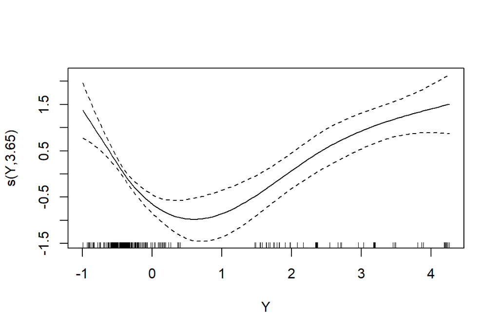

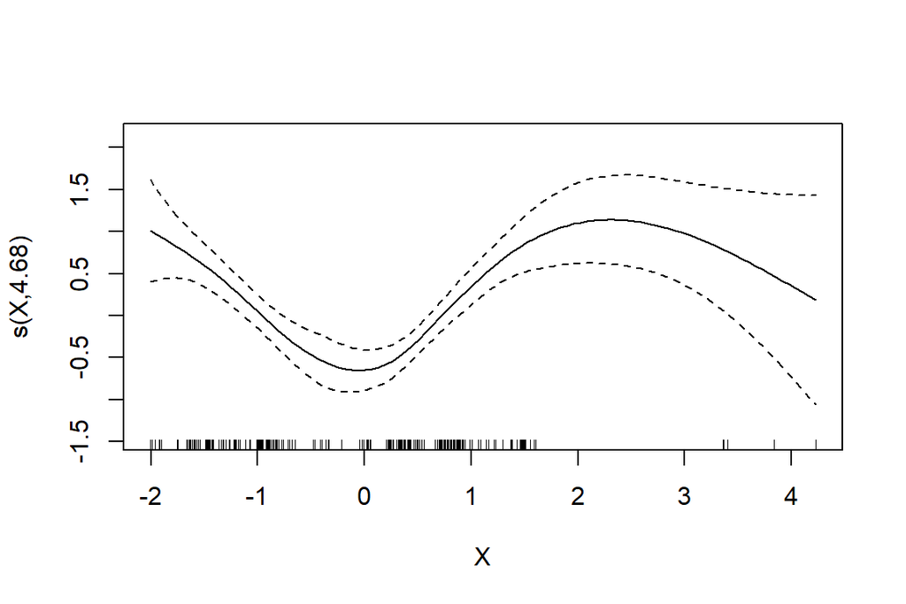

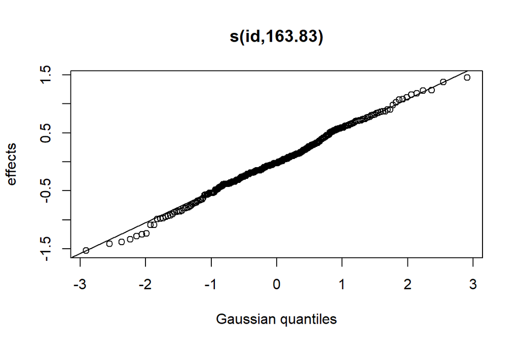

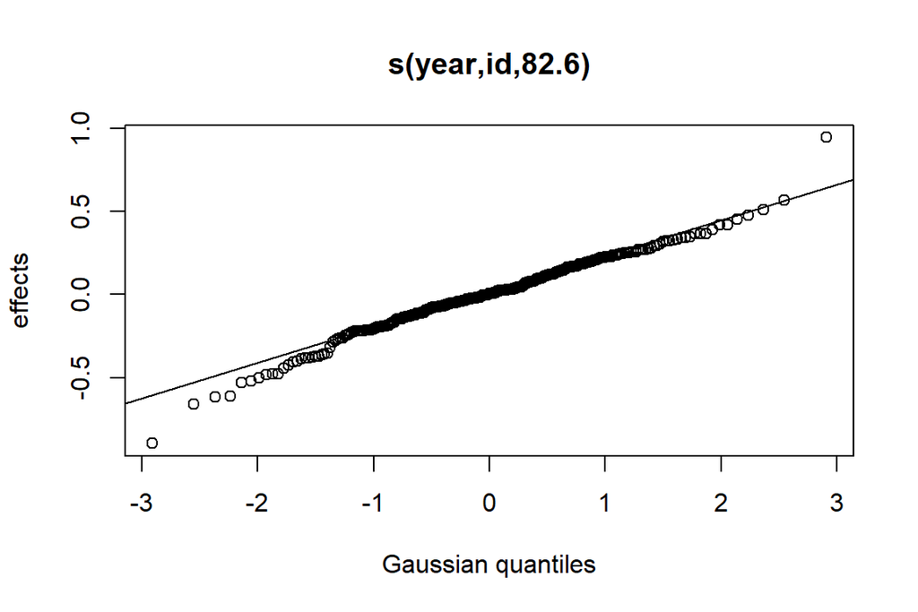

```r
plot(M3)
```

```r
M3$gam
```

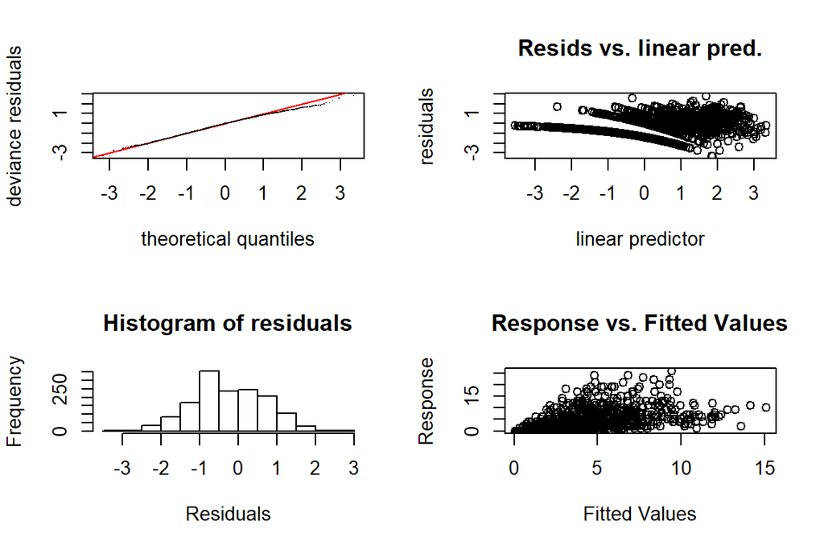

```
##
## Method: ML   Optimizer: outer newton
## full convergence after 6 iterations.
## Gradient range [-4.145927e-06,4.992726e-10]
## (score 2635.345 & scale 1).
## Hessian positive definite, eigenvalue range [1.442367,38.85144].
## Model rank =  584 / 584
##
## Basis dimension (k) checking results. Low p-value (k-index<1) may
## indicate that k is too low, especially if edf is close to k'.
##
##                k'    edf k-index p-value
## s(Y)         9.00   3.65    0.80  <2e-16 ***
## s(X)         9.00   4.68    0.81  <2e-16 ***
## s(id)      277.00 163.83      NA      NA
## s(year,id) 277.00  82.60      NA      NA
## ---
## Signif. codes:  0 '***' 0.001 '**' 0.01 '*' 0.05 '.' 0.1 ' ' 1
```

```r
gam.check(M3)
```

Tsekkaan huvikseen M5:sen.

```r
summary(M5)
```

```
##
## Family: Negative Binomial(18.015)
## Link function: log
##
## Formula:
## terri ~ Abuild + Astream + Aroad + Ariver + agri5 * year + s(Y,
##     bs = "cs") + s(X, bs = "cs") + year * temp + year * prec +
##     year * shanG + year * open + s(id, bs = "re") + s(year, id,
##     bs = "re")
##
## Parametric coefficients:
##             Estimate Std. Error z value Pr(>|z|)
## (Intercept)  1.01481    0.06122  16.576  < 2e-16 ***
## Abuild      -0.01872    0.07918  -0.236 0.813085
## Astream      0.03923    0.06121   0.641 0.521619
## Aroad        0.02960    0.07243   0.409 0.682802
## Ariver       0.20613    0.05534   3.725 0.000195 ***
## agri5        0.28135    0.06932   4.059 4.94e-05 ***
## year        -0.57990    0.05128 -11.308  < 2e-16 ***
## temp         0.05378    0.02410   2.231 0.025653 *
## prec        -0.02087    0.02395  -0.871 0.383699
## shanG        0.02176    0.03134   0.694 0.487550
## open        -0.02168    0.03914  -0.554 0.579655
## agri5:year   0.04433    0.04916   0.902 0.367231
## year:temp    0.04778    0.02281   2.094 0.036245 *
## year:prec   -0.05691    0.02042  -2.786 0.005331 **
## year:shanG   0.05096    0.03085   1.652 0.098598 .
## year:open    0.03304    0.03872   0.853 0.393430
## ---
## Signif. codes:  0 '***' 0.001 '**' 0.01 '*' 0.05 '.' 0.1 ' ' 1
##
## Approximate significance of smooth terms:
##                edf Ref.df Chi.sq  p-value
## s(Y)         3.648      9   5209  < 2e-16 ***
## s(X)         4.667      9   2635 2.48e-09 ***
## s(id)      162.730    276   1927 1.42e-05 ***
## s(year,id)  83.185    276   1923  0.00224 **
## ---
## Signif. codes:  0 '***' 0.001 '**' 0.01 '*' 0.05 '.' 0.1 ' ' 1
##
## R-sq.(adj) =   0.77   Deviance explained = 60.8%
## -ML = 2633.1  Scale est. = 1         n = 1474
```

Pitäisikö plotata vielä tarkemmin kukin muuttuja vs. residuaalit?

### 2.2.5 GAMM, NB, offset, (1 + vuosi|lauluryhmä)

Lisäsin näihin malleihin myös agri5-muuttujalle interaktion vuoden kanssa.

**Pinta-ala muuttujana vai offsettina?**

*Eräästä esimerkistä*: If you are going to model using the Poisson you have to have integer values for your response variable. You then have two options:

-Use area or some other suitable denominator as an offset. This would usually need to be logged first

-Include area or etc as a predictor variable. Again this would usually be included as a log because you are modelling the log counts.

If you use the offset approach you are saying that if I double the area I would expect to get double the count. If you use the predictor approach you are sayinh that you know if you multiply the area you multiply the counts but not necessarily by the same factor.

**Pinta-ala offset argumenttina vai osana mallia?** “Argumenttina: Can be used to supply a model offset for use in fitting. Note that this offset will always be completely ignored when predicting, unlike an offset included in formula (this used to conform to the behaviour of lm and glm).” Eli jos argumenttina niin predicted arvot eivät huomioi offsettia. Kumpikohan olis fiksumpi? Ennusteethan pitäisi siis tehdä jonkun kokoiselle osapopulaatiolle.

**Random intercept ja random slope malli**

Random-muuttujan rakenne (lmer) cheat sheet [tässä](https://stats.stackexchange.com/questions/13166/rs-lmer-cheat-sheet).

V1 ~ (1+V3|V2) + V3

P1: A global intercept

P2: Random effect intercepts for V2 (i.e. for each level of V2, that level’s intercept’s deviation from the global intercept)

P3: A single global estimate for the effect (slope) of V3

P4: The effect of V3 within each level of V2 (more specifically, the degree to which the V3 effect within a given level deviates from the global effect of V3)

P5: The correlation between intercept deviations and V3 deviations across levels of V2

Eli intercept voi vaihdella kunkin lauluryhmän mukaan (lähtökohtaisesti joillain osapopulaatioilla on enemmän tai vähemmän reviirejä, joten yleistä mallia vääntäessä tämä vaihtelu pitää sallia ja ottaa huomioon). Random intercept malli kertoo kuinka paljon osapopulaatioiden välillä on “selittämätöntä” vaihtelua, eli vaihtelua siinä, miten paljon reviirien määrä johtuu jostain muuusta kuin fixed osan muuttujista.

Vuoden vaikutus reviirien määrään (slope) voi myös vaihdella osapopulaatioiden välillä. Jossain lasku on jyrkempi ja jossain loivempi. Slope ja intercept voivat korreloida jossain määrin keskenään eli esimerkiksi osapopulaatioilla, joilla on enemmän reviirejä myös vuosittainen lasku reviirien määrässä on jyrkempi. Tai toisinpäin.

**Mikä R-paketti valitaan?**

Zuurin kommentit paketin valinnasta:  
What package should we use for a GAMM?

Function Package Uses Object names  
gamm4 gamm4 lme4 M1_mer M1_gam  
gamm mgcv nlme M1_lme M1_gam

To gamm4 or to mgcv?  
Gaussian: gamm4 or gamm  
Crossed random effects: use gamm4

Model heterogeneity: nlme but not in lme4. Use gamm  
Model correlation: Y_s = Covariate stuff_s + eps_s  
eps_s = rho * eps_s-1 + Pure Noise  
But….this is all in nlme….(gls and lme)..so only in gamm

Poisson/binomial:  
Use gamm4/lme4 ….you can compare AICs  
But also in gamm….but via PQL …therefore…cannot compare AICs

Adding correlation in Gaussian models:  
T1 <- gamm(Y ~ s(X), correlation = corAR1(form=~ Time))  
T1 <- gamm(Y ~ s(X), correlation = corSpher(form=~ Lat+Lon))

**Miten gamm malleja vertaillaan?**

AIC ei kai ihan pätevä. gamm4 ja gamm funktioilla on ilmeisesti eroa. Katso Zuurin pingviiniesimerkit. Miten vapausasteet lasketaan gammeilla? smoothereissa on lineaarinen ja random osa? Eli yksi vai kaksi vapausastetta? Ratkaisee sen miten AIC lasketaan. Asiasta ei kai olla ihan yhtä mieltä. Zuur neuvoo tekemään analyysit Bayeslaisittain, jolloin tätä ongelmaa ei ole. Vai onko tämä ongelma vasta sitten kun vertailtavien mallien AIC arvot ovat hyvin lähekkäin. Jos niiden välillä on selvä ero -> AIC arvoihin voi luottaa??

mgvc.FAQ ([täällä](https://stat.ethz.ch/R-manual/R-devel/library/mgcv/html/mgcv-FAQ.html)):

*When using gamm or gamm4, the reported AIC is different for the gam object and the lme or lmer object. Why is this?* There are several reasons for this. The most important is that the models being used are actually different in the two representations. When treating the GAM as a mixed model, you are implicitly assuming that if you gathered a replicate dataset, the smooths in your model would look completely different to the smooths from the original model, except for having the same degree of smoothness. Technically you would expect the smooths to be drawn afresh from their distribution under the random effects model. When viewing the gam from the usual penalized regression perspective, you would expect smooths to look broadly similar under replication of the data. i.e. you are really using Bayesian model for the smooths, rather than a random effects model (it’s just that the frequentist random effects and Bayesian computations happen to coincide for computing the estimates). As a result of the different assumptions about the data generating process, AIC model comparisons can give rather different answers depending on the model adopted. Which you use should depend on which model you really think is appropriate. In addition the computations of the AICs are different. The mixed model AIC uses the marginal likelihood and the corresponding number of model parameters. The gam model uses the penalized likelihood and the effective degrees of freedom.

*How can I compare gamm models?* In the identity link normal errors case, then AIC and hypotheis testing based methods are fine. Otherwise it is best to work out a strategy based on the summary.gam Alternatively, simple random effects can be fitted with gam, which makes comparison straightforward. Package gamm4 is an alternative, which allows AIC type model selection for generalized models.

**Temporaalinen autokorrelaatio?** Peräkkäiset vuodet ovat reviirimäärältään samankaltaisempia kuin kauempana toisistaan olevat vuodet? corAR1 jutska.

**Negative binomial jakauman Theta?** gamm4-funktion negbin jakaumaan pitää määritellä theta. Miten se valitaan?

Zuurin kaksi tapaa arvioida theta:

1. Käytetään gamm4-funktiota ja kokeillaan erilaisia thetoja, katsotaan kuvaajasta, mikä antaa parhaimman AIC arvon

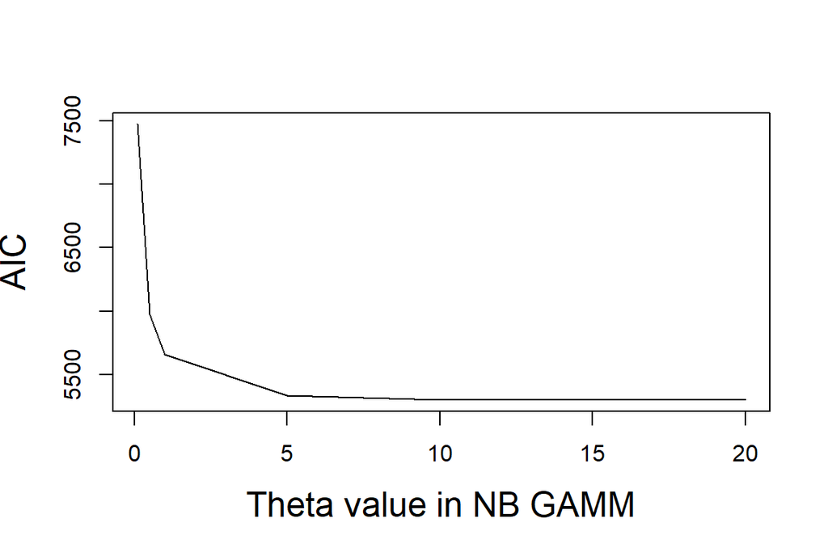

```r
AllThetas <- c(0.1, 0.5, 1, 5, 10,20)
AICs <- vector(length = 6)
i <- 1
for (MyTheta in AllThetas) {
       M1 <- gamm4(terri ~ Abuild + Astream + Aroad + Ariver + agri5*year + s(Y) + s(X) + year*temp + year*prec + year*shanG + year*open + offset(log(area)),
                random =~ (1 + year| id),
                family = negbin(theta = MyTheta),
                data = dataS)
       AICs[i] <- AIC(M1$mer)  #<---
       i <- i + 1
}
# And plot the results
plot(x = AllThetas,
     y = AICs,
     xlab = "Theta value in NB GAMM",
     ylab = "AIC",
     cex.lab = 1.5,
     type = "l"
    )
```

Tästä ei tule tulokseksi mitään järkeävää. Tai AIC:t vaan laskee mitä isompi theta on. Onko se järkevä tulos?

2. Käytetään gam-funktiota, jolloin family=nb() arvioi itse sopivan thetan. Tässä tulee taas ongelmaksi gam-funktion random-rakenne. Miten siihen ohjelmoidaan oikeanlainen random intercept ja slope rakenne? Koodissa on nyt toistaiseksi rakenne, joka ymmärtääkseni ei salli korrelaatiota slopen ja interceptin välillä (eli (0 + year|id)). Voiko thetan arvioida näin?

```r
#thetan voisi arvioida sovittamalla mallin GAM:lla eli random tekijä smootheriksi. Mutta mikä malli tässä pitäisi olla? Monimutkaisin?

M6 <- gam(terri ~ Abuild + Astream + Aroad + Ariver + agri5*year + s(Y) + s(X) + year*temp + year*prec + year*shanG + year*open + offset(log(area)) + s(id, bs="re") + s(year,id, bs="re"), family = nb(),data = dataS)
summary(M6)
```

```
##
## Family: Negative Binomial(17.056)
## Link function: log
##
## Formula:
## terri ~ Abuild + Astream + Aroad + Ariver + agri5 * year + s(Y) +
##     s(X) + year * temp + year * prec + year * shanG + year *
##     open + offset(log(area)) + s(id, bs = "re") + s(year, id,
##     bs = "re")
##
## Parametric coefficients:
##              Estimate Std. Error z value Pr(>|z|)
## (Intercept)  1.002275   0.062384  16.066  < 2e-16 ***
## Abuild      -0.001969   0.080956  -0.024 0.980591
## Astream      0.034958   0.062970   0.555 0.578797
## Aroad        0.018247   0.074152   0.246 0.805627
## Ariver       0.202159   0.056526   3.576 0.000348 ***
## agri5        0.297353   0.072837   4.082 4.46e-05 ***
## year        -0.599433   0.052440 -11.431  < 2e-16 ***
## temp         0.053145   0.024290   2.188 0.028671 *
## prec        -0.021761   0.024121  -0.902 0.366980
## shanG        0.018874   0.031750   0.594 0.552201
## open        -0.023857   0.039728  -0.601 0.548164
## agri5:year   0.048945   0.050891   0.962 0.336178
## year:temp    0.048716   0.023012   2.117 0.034257 *
## year:prec   -0.057073   0.020563  -2.776 0.005511 **
## year:shanG   0.051830   0.031183   1.662 0.096491 .
## year:open    0.033933   0.039203   0.866 0.386722
## ---
## Signif. codes:  0 '***' 0.001 '**' 0.01 '*' 0.05 '.' 0.1 ' ' 1
##
## Approximate significance of smooth terms:
##                edf  Ref.df Chi.sq  p-value
## s(Y)         5.312   5.562   88.8  < 2e-16 ***
## s(X)         5.473   5.769   62.3 1.79e-11 ***
## s(id)      161.763 274.000 1910.1 3.55e-05 ***
## s(year,id)  83.757 276.000 1946.9  0.00323 **
## ---
## Signif. codes:  0 '***' 0.001 '**' 0.01 '*' 0.05 '.' 0.1 ' ' 1
##
## R-sq.(adj) =   0.77   Deviance explained =   61%
## -REML = 2665.6  Scale est. = 1         n = 1474
```

```r
Theta <- M6$family$getTheta(TRUE)


# If you want then you can run M1 again with the optimal theta.
M7 <- gamm4(terri ~ Abuild + Astream + Aroad + Ariver + agri5*year + s(Y) + s(X) + year*temp + year*prec + year*shanG + year*open + offset(log(area)),
            random = ~(1 + year|id),
            family = negbin(theta = Theta),
            data = dataS)

# M6 and M7 should now give similar results.
summary(M6)
```

```
##
## Family: Negative Binomial(17.056)
## Link function: log
##
## Formula:
## terri ~ Abuild + Astream + Aroad + Ariver + agri5 * year + s(Y) +
##     s(X) + year * temp + year * prec + year * shanG + year *
##     open + offset(log(area)) + s(id, bs = "re") + s(year, id,
##     bs = "re")
##
## Parametric coefficients:
##              Estimate Std. Error z value Pr(>|z|)
## (Intercept)  1.002275   0.062384  16.066  < 2e-16 ***
## Abuild      -0.001969   0.080956  -0.024 0.980591
## Astream      0.034958   0.062970   0.555 0.578797
## Aroad        0.018247   0.074152   0.246 0.805627
## Ariver       0.202159   0.056526   3.576 0.000348 ***
## agri5        0.297353   0.072837   4.082 4.46e-05 ***
## year        -0.599433   0.052440 -11.431  < 2e-16 ***
## temp         0.053145   0.024290   2.188 0.028671 *
## prec        -0.021761   0.024121  -0.902 0.366980
## shanG        0.018874   0.031750   0.594 0.552201
## open        -0.023857   0.039728  -0.601 0.548164
## agri5:year   0.048945   0.050891   0.962 0.336178
## year:temp    0.048716   0.023012   2.117 0.034257 *
## year:prec   -0.057073   0.020563  -2.776 0.005511 **
## year:shanG   0.051830   0.031183   1.662 0.096491 .
## year:open    0.033933   0.039203   0.866 0.386722
## ---
## Signif. codes:  0 '***' 0.001 '**' 0.01 '*' 0.05 '.' 0.1 ' ' 1
##
## Approximate significance of smooth terms:
##                edf  Ref.df Chi.sq  p-value
## s(Y)         5.312   5.562   88.8  < 2e-16 ***
## s(X)         5.473   5.769   62.3 1.79e-11 ***
## s(id)      161.763 274.000 1910.1 3.55e-05 ***
## s(year,id)  83.757 276.000 1946.9  0.00323 **
## ---
## Signif. codes:  0 '***' 0.001 '**' 0.01 '*' 0.05 '.' 0.1 ' ' 1
##
## R-sq.(adj) =   0.77   Deviance explained =   61%
## -REML = 2665.6  Scale est. = 1         n = 1474
```

```r
summary(M7$gam)
```

```
##
## Family: Negative Binomial(17.056)
## Link function: log
##
## Formula:
## terri ~ Abuild + Astream + Aroad + Ariver + agri5 * year + s(Y) +
##     s(X) + year * temp + year * prec + year * shanG + year *
##     open + offset(log(area))
##
## Parametric coefficients:
##              Estimate Std. Error z value Pr(>|z|)
## (Intercept)  0.913246   0.056755  16.091  < 2e-16 ***
## Abuild       0.007087   0.075243   0.094 0.924955
## Astream      0.048980   0.060529   0.809 0.418403
## Aroad        0.040260   0.071466   0.563 0.573202
## Ariver       0.188048   0.055398   3.394 0.000688 ***
## agri5        0.315595   0.068135   4.632 3.62e-06 ***
## year        -0.559874   0.047955 -11.675  < 2e-16 ***
## temp         0.062169   0.024180   2.571 0.010137 *
## prec        -0.023670   0.024097  -0.982 0.325958
## shanG        0.033568   0.031222   1.075 0.282315
## open        -0.004701   0.038419  -0.122 0.902617
## agri5:year   0.072097   0.047251   1.526 0.127052
## year:temp    0.058701   0.022813   2.573 0.010080 *
## year:prec   -0.057528   0.020520  -2.804 0.005054 **
## year:shanG   0.034924   0.030421   1.148 0.250959
## year:open    0.016605   0.037334   0.445 0.656485
## ---
## Signif. codes:  0 '***' 0.001 '**' 0.01 '*' 0.05 '.' 0.1 ' ' 1
##
## Approximate significance of smooth terms:
##        edf Ref.df Chi.sq  p-value
## s(Y) 5.194  5.194  88.84  < 2e-16 ***
## s(X) 5.227  5.227  57.62 7.56e-11 ***
## ---
## Signif. codes:  0 '***' 0.001 '**' 0.01 '*' 0.05 '.' 0.1 ' ' 1
##
## R-sq.(adj) =  0.493
## glmer.ML = 1328.1  Scale est. = 1         n = 1474
```

```r
summary(M7$mer)
```

```
## Generalized linear mixed model fit by maximum likelihood (Laplace
##   Approximation) [glmerMod]
##  Family: Negative Binomial(17.056)  ( log )
##
##      AIC      BIC   logLik deviance df.resid
##   5300.0   5427.1  -2626.0   5252.0     1450
##
## Scaled residuals:
##     Min      1Q  Median      3Q     Max
## -2.1600 -0.6671 -0.2939  0.4993  4.0346
##
## Random effects:
##  Groups Name        Variance Std.Dev. Corr
##  id     (Intercept)  0.4562  0.6754
##         year         0.1645  0.4055   0.42
##  Xr.0   s(X)         6.6567  2.5801
##  Xr     s(Y)        13.4189  3.6632
## Number of obs: 1474, groups:  id, 277; Xr.0, 8; Xr, 8
##
## Fixed effects:
##                 Estimate Std. Error z value Pr(>|z|)
## X.0(Intercept)  0.913246   0.059929  15.239  < 2e-16 ***
## X.0Abuild       0.007087   0.076992   0.092 0.926655
## X.0Astream      0.048980   0.060794   0.806 0.420431
## X.0Aroad        0.040260   0.073475   0.548 0.583736
## X.0Ariver       0.188048   0.056647   3.320 0.000901 ***
## X.0agri5        0.315595   0.074706   4.224  2.4e-05 ***
## X.0year        -0.559874   0.062807  -8.914  < 2e-16 ***
## X.0temp         0.062169   0.024321   2.556 0.010583 *
## X.0prec        -0.023670   0.023822  -0.994 0.320421
## X.0shanG        0.033568   0.031580   1.063 0.287809
## X.0open        -0.004701   0.038640  -0.122 0.903173
## X.0agri5:year   0.072097   0.048048   1.501 0.133480
## X.0year:temp    0.058701   0.023083   2.543 0.010989 *
## X.0year:prec   -0.057528   0.020357  -2.826 0.004713 **
## X.0year:shanG   0.034924   0.031264   1.117 0.263962
## X.0year:open    0.016605   0.037830   0.439 0.660700
## X.0s(Y)Fx1     -1.175793   0.640214  -1.837 0.066274 .
## X.0s(X)Fx1     -0.184443   0.598651  -0.308 0.758008
## ---
## Signif. codes:  0 '***' 0.001 '**' 0.01 '*' 0.05 '.' 0.1 ' ' 1
```

```
##
## Correlation matrix not shown by default, as p = 18 > 12.
## Use print(x, correlation=TRUE)  or
##     vcov(x)        if you need it
```

```r
gam.vcomp(M6)
```

```
##
## Standard deviations and 0.95 confidence intervals:
##
##              std.dev     lower     upper
## s(Y)       2.0362195 0.6967085 5.9511113
## s(X)       1.5329723 0.7194538 3.2663725
## s(id)      0.7392215 0.6255037 0.8736135
## s(year,id) 0.4359336 0.3382676 0.5617981
##
## Rank: 4/4
```

Ei nää mallit nyt ihan täsmää keskenään vaikka pitäisi. Siis jos vertailee muuttujille ja interceptille arvioituja parametreja. Ja random-muuttujien std.dev arvoja. Mutta jos tästä silti ottaisi tuon Thetan onkeensa.

```r
Theta
```

```
## [1] 17.05631
```

Jos tässä kokeilussa oli väärin käyttää tuota monimutkaisinta mallia niin kokeillaan sitten myös yksinkertaisemmalla mallilla. Saanko saman thetan?

```r
M8 <- gam(terri ~ year + offset(log(area)) + s(id, bs="re") + s(year,id, bs="re"), family = nb(), data = dataS)
summary(M8)
```

```
##
## Family: Negative Binomial(14.027)
## Link function: log
##
## Formula:
## terri ~ year + offset(log(area)) + s(id, bs = "re") + s(year,
##     id, bs = "re")
##
## Parametric coefficients:
##             Estimate Std. Error z value Pr(>|z|)
## (Intercept)  1.29112    0.07131   18.11   <2e-16 ***
## year        -0.52633    0.04912  -10.71   <2e-16 ***
## ---
## Signif. codes:  0 '***' 0.001 '**' 0.01 '*' 0.05 '.' 0.1 ' ' 1
##
## Approximate significance of smooth terms:
##               edf Ref.df Chi.sq  p-value
## s(id)      207.75    276   3753 3.40e-11 ***
## s(year,id)  70.26    276   6803 3.21e-07 ***
## ---
## Signif. codes:  0 '***' 0.001 '**' 0.01 '*' 0.05 '.' 0.1 ' ' 1
##
## R-sq.(adj) =  0.746   Deviance explained = 59.4%
## -REML = 2706.5  Scale est. = 1         n = 1474
```

```r
Theta2 <- M8$family$getTheta(TRUE)


# If you want then you can run M4 again with the optimal theta.
M9 <- gamm4(terri ~ year + offset(log(area)),
            random = ~(1 + year|id),
            family = negbin(theta = Theta2),
            data = dataS)

Theta2
```

```
## [1] 14.02726
```

Nyt theta on 14.02726 eli eroaa edellisestä arviosta jonkin verran. Zuurin esimerkki ei selitä, mitä mallia thetan arvioinnissa pitäisi käyttää. Siinä käytetään mallia, johon on jo aiemmista kiemuroista päädytty, eikä esimerkissä tehdä mallin valintaa tämän jälkeen (etsitään vain sopiva theta ja sovitetaan negbin malli).

Nyt en oikein tiedä minkä thetan valitsisin. Toistaiseksi valitsen tuon ekan vaihtoehdon, jonka etsimisessä käytettiin monimutkaisempaa mallia.

Nyt takaisin varsinaisten mallien pariin kun theta on arvioitu:

```r
#varsinaiset mallit, joissa theta arvioitu gam-mallin avulla

G1=gamm4(terri ~ year + offset(log(area)), random= ~(1 + year|id), family=negbin(theta=Theta), data=dataS)

G2=gamm4(terri ~ Abuild + Astream + Aroad + Ariver + agri5*year + s(Y) + s(X) + year + offset(log(area)), random= ~(1 + year|id), family=negbin(theta=Theta), data=dataS)

G3=gamm4(terri ~ Abuild + Astream + Aroad + Ariver + agri5*year + s(Y) + s(X)+ year*temp + year*prec + offset(log(area)), random= ~(1 + year|id), family=negbin(theta=Theta), data=dataS)

G4=gamm4(terri ~ Abuild + Astream + Aroad + Ariver + agri5*year + s(Y) + s(X) + year*shanG + year*open + offset(log(area)), random= ~(1 + year|id), family=negbin(theta=Theta), data=dataS)

G5=gamm4(terri ~ Abuild + Astream + Aroad + Ariver + agri5*year + s(Y) + s(X) + year*temp + year*prec + year*shanG + year*open + offset(log(area)), random= ~(1 + year|id), family=negbin(theta=Theta), data=dataS)
```

```r
AIC(G1$mer, G2$mer, G3$mer, G4$mer, G5$mer)
```

```
##        df      AIC
## G1$mer  6 5402.907
## G2$mer 16 5310.317
## G3$mer 20 5294.812
## G4$mer 20 5315.318
## G5$mer 24 5300.034
```

```r
anova(G1$mer, G2$mer, G3$mer, G4$mer, G5$mer)
```

```
## Data: NULL
## Models:
## G1$mer: NULL
## G2$mer: NULL
## G3$mer: NULL
## G4$mer: NULL
## G5$mer: NULL
##        Df    AIC    BIC  logLik deviance   Chisq Chi Df Pr(>Chisq)
## G1$mer  6 5402.9 5434.7 -2695.4   5390.9
## G2$mer 16 5310.3 5395.0 -2639.2   5278.3 112.590     10  < 2.2e-16 ***
## G3$mer 20 5294.8 5400.7 -2627.4   5254.8  23.505      4  0.0001004 ***
## G4$mer 20 5315.3 5421.2 -2637.7   5275.3   0.000      0  1.0000000
## G5$mer 24 5300.0 5427.1 -2626.0   5252.0  23.284      4  0.0001111 ***
## ---
## Signif. codes:  0 '***' 0.001 '**' 0.01 '*' 0.05 '.' 0.1 ' ' 1
```

G3 ja G5 näyttävät saavan pienimmät AIC arvot.  
Mutta joissain esimerkeissä vertaillaan BIC arvoja, näissä mitattuna G2 olisi paras.

```r
summary(G3$gam)
```

```
##
## Family: Negative Binomial(17.056)
## Link function: log
##
## Formula:
## terri ~ Abuild + Astream + Aroad + Ariver + agri5 * year + s(Y) +
##     s(X) + year * temp + year * prec + offset(log(area))
##
## Parametric coefficients:
##              Estimate Std. Error z value Pr(>|z|)
## (Intercept)  0.910471   0.056493  16.116  < 2e-16 ***
## Abuild       0.007908   0.075038   0.105  0.91606
## Astream      0.043727   0.060358   0.724  0.46878
## Aroad        0.039763   0.071411   0.557  0.57765
## Ariver       0.183253   0.055446   3.305  0.00095 ***
## agri5        0.318392   0.068095   4.676 2.93e-06 ***
## year        -0.552658   0.047275 -11.690  < 2e-16 ***
## temp         0.063573   0.024019   2.647  0.00813 **
## prec        -0.023092   0.024022  -0.961  0.33641
## agri5:year   0.076809   0.047082   1.631  0.10281
## year:temp    0.059880   0.022713   2.636  0.00838 **
## year:prec   -0.056029   0.020461  -2.738  0.00618 **
## ---
## Signif. codes:  0 '***' 0.001 '**' 0.01 '*' 0.05 '.' 0.1 ' ' 1
##
## Approximate significance of smooth terms:
##        edf Ref.df Chi.sq  p-value
## s(Y) 5.305  5.305  87.41  < 2e-16 ***
## s(X) 5.222  5.222  56.63 1.17e-10 ***
## ---
## Signif. codes:  0 '***' 0.001 '**' 0.01 '*' 0.05 '.' 0.1 ' ' 1
##
## R-sq.(adj) =  0.496
## glmer.ML = 1329.5  Scale est. = 1         n = 1474
```

```r
summary(G3$mer)
```

```
## Generalized linear mixed model fit by maximum likelihood (Laplace
##   Approximation) [glmerMod]
##  Family: Negative Binomial(17.056)  ( log )
##
##      AIC      BIC   logLik deviance df.resid
##   5294.8   5400.7  -2627.4   5254.8     1454
##
## Scaled residuals:
##     Min      1Q  Median      3Q     Max
## -2.1648 -0.6587 -0.2957  0.4926  3.9304
##
## Random effects:
##  Groups Name        Variance Std.Dev. Corr
##  id     (Intercept)  0.4601  0.6783
##         year         0.1655  0.4068   0.45
##  Xr.0   s(X)         6.5404  2.5574
##  Xr     s(Y)        14.6874  3.8324
## Number of obs: 1474, groups:  id, 277; Xr.0, 8; Xr, 8
##
## Fixed effects:
##                 Estimate Std. Error z value Pr(>|z|)
## X.0(Intercept)  0.910471   0.059821  15.220  < 2e-16 ***
## X.0Abuild       0.007908   0.076791   0.103  0.91797
## X.0Astream      0.043727   0.060744   0.720  0.47162
## X.0Aroad        0.039763   0.073471   0.541  0.58836
## X.0Ariver       0.183253   0.056614   3.237  0.00121 **
## X.0agri5        0.318392   0.075377   4.224  2.4e-05 ***
## X.0year        -0.552658   0.061476  -8.990  < 2e-16 ***
## X.0temp         0.063573   0.024147   2.633  0.00847 **
## X.0prec        -0.023092   0.023754  -0.972  0.33098
## X.0agri5:year   0.076809   0.047725   1.609  0.10752
## X.0year:temp    0.059880   0.022929   2.612  0.00901 **
## X.0year:prec   -0.056029   0.020305  -2.759  0.00579 **
## X.0s(Y)Fx1     -1.164908   0.651649  -1.788  0.07384 .
## X.0s(X)Fx1     -0.169118   0.592346  -0.286  0.77526
## ---
## Signif. codes:  0 '***' 0.001 '**' 0.01 '*' 0.05 '.' 0.1 ' ' 1
```

```
##
## Correlation matrix not shown by default, as p = 14 > 12.
## Use print(x, correlation=TRUE)  or
##     vcov(x)        if you need it
```

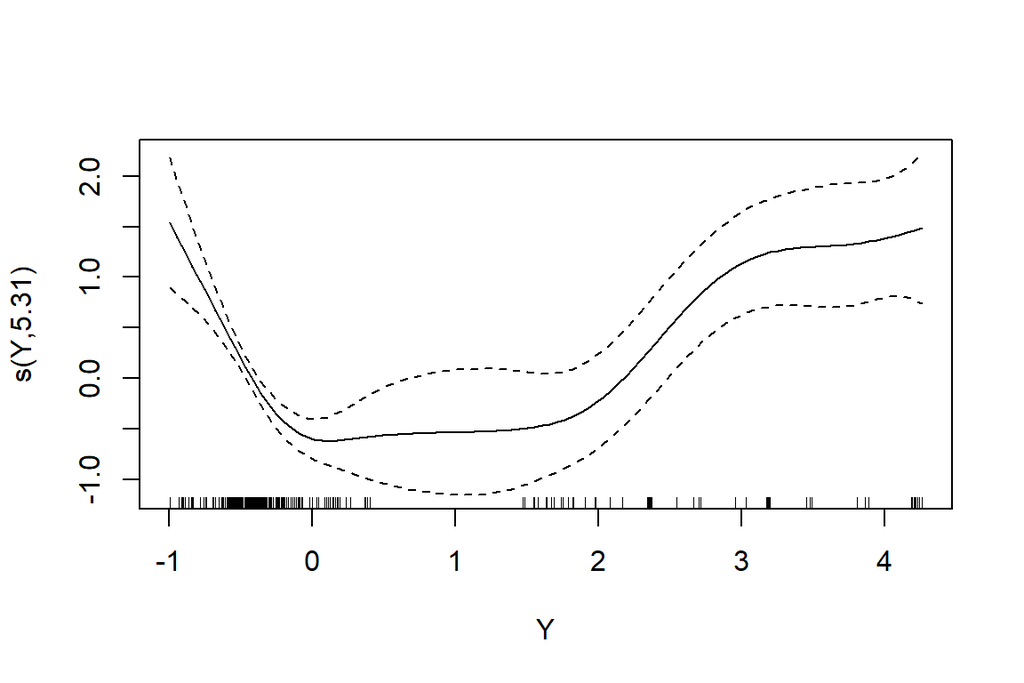

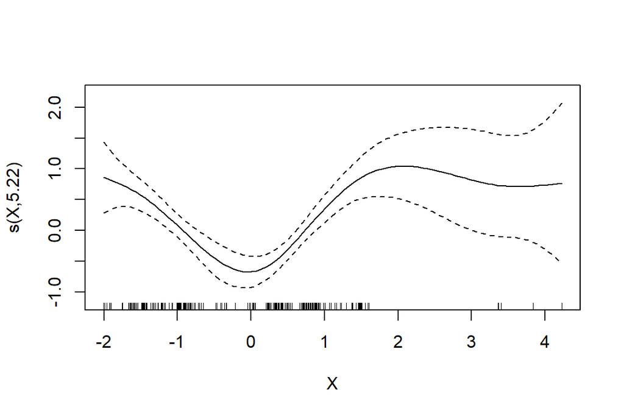

```r
plot(G3$gam)
```

Hmm.. Mitähän näistä nyt sanoisi?

**Mallin validointia seuraavaksi.**  
Ilmeisesti NB voi myös olla overdispersed.

```r
#Check dispersion parameter
p <- sum(G3$gam$edf) + 1 + 1 #theta and sigma id,  MITÄ TÄHÄN PITÄISI KIRJATA, tuleeko crossed random effectseistä vielä yksi degree of freedom lisää? vielä yksi +1?
N <- nrow(dataS)
E4 <- resid(G3$mer, type = "pearson")
Overdisp <- sum(E4^2) / (N - p)
Overdisp
```

```
## [1] 0.7448147
```

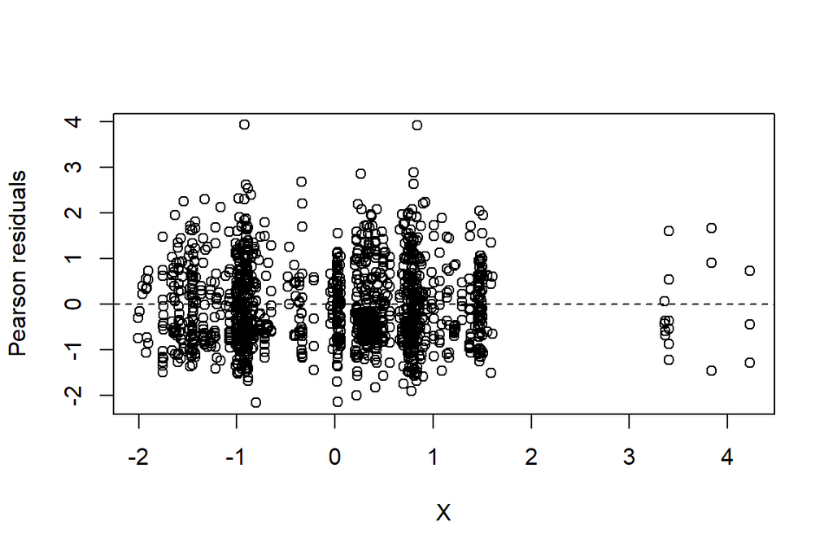

```r
#Plot residuals vs ...
plot(x = dataS$X,
     y = E4,
     xlab = "X",
     ylab = "Pearson residuals")
abline(h = 0, lty = 2)
```

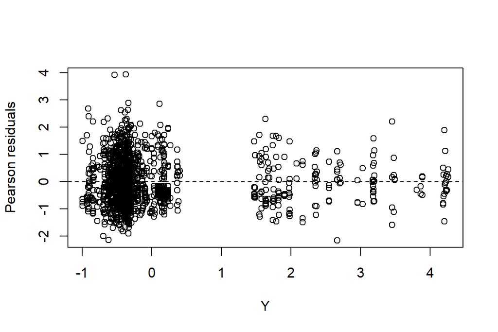

```r
#Plot residuals vs ...
plot(x = dataS$Y,
     y = E4,
     xlab = "Y",
     ylab = "Pearson residuals")
abline(h = 0, lty = 2)
```

```r
#Is there a non-linear pattern in here?
T1 <- gam(E4 ~ s(Y), data = dataS)
summary(T1)
```

```
##
## Family: gaussian
## Link function: identity
##
## Formula:
## E4 ~ s(Y)
##
## Parametric coefficients:
##             Estimate Std. Error t value Pr(>|t|)
## (Intercept) -0.06835    0.02223  -3.074  0.00215 **
## ---
## Signif. codes:  0 '***' 0.001 '**' 0.01 '*' 0.05 '.' 0.1 ' ' 1
##
## Approximate significance of smooth terms:
##      edf Ref.df     F p-value
## s(Y)   1      1 0.017   0.896
##
## R-sq.(adj) =  -0.000668   Deviance explained = 0.00115%
## GCV = 0.72972  Scale est. = 0.72873   n = 1474
```

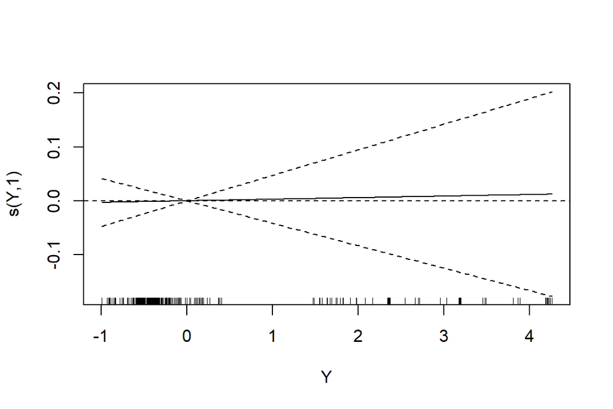

```r
plot(T1)
abline(h = 0, lty = 2)
```

Tää validointi on Zuurin GAMM NB esimerkistä. En vielä osaa sen kummemmin tulkita näitä. Enkä tiedä mitä kaikkea pitäisi plotata.

### 2.2.6 gamm-funktio

Samat mallit voisi ajaa myös gamm-funktiolla. gamm-funktion etu olisi se, että sen negative binomial jakaumaan ei tarvitse määrittää thetaa. Arvioi kai sen itse (?) Mutta miten tehdään mallin vertailu jos AIC ei ole käytettävissä? Paitsi, että Zuurin kirjassa AIC vertailua tehdään kyllä ihan mennen tullen.

Näissä malleissa pinta-alan logaritmi on argumentti-offsettina.

```r
G1=gamm(terri ~ year, offset=log(area), random= list(id=~1+year), family=nbinom2, data=dataS)
```

```
##
##  Maximum number of PQL iterations:  20
```

[output not shown]

[output not shown]

[output not shown]

[output not shown]

[output not shown]

[output not shown]

[output not shown]

[output not shown]

[output not shown]

```r
G2=gamm(terri ~ Abuild + Astream + Aroad + Ariver + agri5*year + s(Y,bs="cr") + s(X,bs="cr") + year, offset=log(area), random= list(id=~1+year), family=nbinom2, data=dataS)
```

```
##
##  Maximum number of PQL iterations:  20
```

[output not shown]

[output not shown]

[output not shown]

[output not shown]

[output not shown]

[output not shown]

[output not shown]

[output not shown]

```r
G3=gamm(terri ~ Abuild + Astream + Aroad + Ariver + agri5*year + s(Y,bs="cr") + s(X,bs="cr")+ year*temp + year*prec , offset=log(area), random= list(id=~1+year), family=nbinom2, data=dataS)
```

```
##
##  Maximum number of PQL iterations:  20
```

[output not shown]

[output not shown]

[output not shown]

[output not shown]

[output not shown]

[output not shown]

[output not shown]

[output not shown]

```r
G4=gamm(terri ~ Abuild + Astream + Aroad + Ariver + agri5*year + s(Y,bs="cr") + s(X,bs="cr") + year*shanG + year*open, offset=log(area), random= list(id=~1+year), family=nbinom2, data=dataS)
```

```
##
##  Maximum number of PQL iterations:  20
```

[output not shown]

[output not shown]

[output not shown]

[output not shown]

[output not shown]

[output not shown]

[output not shown]

[output not shown]

```r
G5=gamm(terri ~ Abuild + Astream + Aroad + Ariver + agri5*year + s(Y,bs="cr") + s(X,bs="cr") + year*temp + year*prec + year*shanG + year*open, offset=log(area), random= list(id=~1+year), family=nbinom2, data=dataS)
```

```
##
##  Maximum number of PQL iterations:  20
```

[output not shown]

[output not shown]

[output not shown]

[output not shown]

[output not shown]

[output not shown]

[output not shown]

[output not shown]

```r
AIC(G1$lme, G2$lme, G3$lme, G4$lme, G5$lme)
```

```
##        df      AIC
## G1$lme  6 4841.897
## G2$lme 16 4811.083
## G3$lme 20 4829.104
## G4$lme 20 4809.900
## G5$lme 24 4827.428
```

Hmm.. Tämän mukaan malli G4 on paras. Mutta unohdetaan tämä vertailu nyt toistaiseksi ja keskitytään vain tuon täyden mallin (G5) analysointiin. Verrataan ensin saako erilaisilla offset-rakenteilla erilaisia tuloksia.

Vähän myös mietityttää malleja sovitettaessa tuo varoitus: “non-list contrasts argument ignored”. Mietin, että johtuisiko se jotenkin tuosta offsetista ja sen asettelusta mutta en keksi mikä siinä olisi väärin. Testaan samaa G5 mallia niin, että offset-argumentin sisällä on Larea. Random-rakenne on myös mielestäni koodattu nyt oikein ja jonkinlaisia tuloksiahan siitäkin saa.

```r
G6=gamm(terri ~ Abuild + Astream + Aroad + Ariver + agri5*year + s(Y,bs="cr") + s(X,bs="cr") + year*temp + year*prec + year*shanG + year*open, offset=Larea, random= list(id=~1+year), family=nbinom2, data=dataS)
```

```
##
##  Maximum number of PQL iterations:  20
```

[output not shown]

[output not shown]

[output not shown]

[output not shown]

[output not shown]

[output not shown]

[output not shown]

[output not shown]

```r
summary(G5$gam)
```

```
##
## Family: nbinom2
## Link function: log
##
## Formula:
## terri ~ Abuild + Astream + Aroad + Ariver + agri5 * year + s(Y,
##     bs = "cr") + s(X, bs = "cr") + year * temp + year * prec +
##     year * shanG + year * open
##
## Parametric coefficients:
##              Estimate Std. Error t value Pr(>|t|)
## (Intercept)  0.321739   0.092573   3.476 0.000525 ***
## Abuild       0.038815   0.111055   0.350 0.726753
## Astream      0.107396   0.085221   1.260 0.207801
## Aroad       -0.139671   0.100862  -1.385 0.166334
## Ariver       0.237456   0.077775   3.053 0.002306 **
## agri5        0.426891   0.102281   4.174 3.17e-05 ***
## year        -0.976422   0.065424 -14.925  < 2e-16 ***
## temp         0.033526   0.030709   1.092 0.275123
## prec        -0.040070   0.030419  -1.317 0.187964
## shanG        0.096521   0.038429   2.512 0.012123 *
## open        -0.004644   0.046072  -0.101 0.919728
## agri5:year   0.107219   0.063178   1.697 0.089893 .
## year:temp    0.068804   0.029707   2.316 0.020693 *
## year:prec   -0.053462   0.026389  -2.026 0.042957 *
## year:shanG   0.045574   0.038042   1.198 0.231119
## year:open    0.005109   0.044923   0.114 0.909467
## ---
## Signif. codes:  0 '***' 0.001 '**' 0.01 '*' 0.05 '.' 0.1 ' ' 1
##
## Approximate significance of smooth terms:
##        edf Ref.df      F  p-value
## s(Y) 3.818  3.818 16.413 1.10e-12 ***
## s(X) 4.684  4.684  8.794 1.11e-07 ***
## ---
## Signif. codes:  0 '***' 0.001 '**' 0.01 '*' 0.05 '.' 0.1 ' ' 1
##
## R-sq.(adj) =  -0.122
##   Scale est. = 0.38846   n = 1474
```

```r
summary(G6$gam)
```

```
##
## Family: nbinom2
## Link function: log
##
## Formula:
## terri ~ Abuild + Astream + Aroad + Ariver + agri5 * year + s(Y,
##     bs = "cr") + s(X, bs = "cr") + year * temp + year * prec +
##     year * shanG + year * open
##
## Parametric coefficients:
##              Estimate Std. Error t value Pr(>|t|)
## (Intercept)  0.321739   0.092573   3.476 0.000525 ***
## Abuild       0.038815   0.111055   0.350 0.726753
## Astream      0.107396   0.085221   1.260 0.207801
## Aroad       -0.139671   0.100862  -1.385 0.166334
## Ariver       0.237456   0.077775   3.053 0.002306 **
## agri5        0.426891   0.102281   4.174 3.17e-05 ***
## year        -0.976422   0.065424 -14.925  < 2e-16 ***
## temp         0.033526   0.030709   1.092 0.275123
## prec        -0.040070   0.030419  -1.317 0.187964
## shanG        0.096521   0.038429   2.512 0.012123 *
## open        -0.004644   0.046072  -0.101 0.919728
## agri5:year   0.107219   0.063178   1.697 0.089893 .
## year:temp    0.068804   0.029707   2.316 0.020693 *
## year:prec   -0.053462   0.026389  -2.026 0.042957 *
## year:shanG   0.045574   0.038042   1.198 0.231119
## year:open    0.005109   0.044923   0.114 0.909467
## ---
## Signif. codes:  0 '***' 0.001 '**' 0.01 '*' 0.05 '.' 0.1 ' ' 1
##
## Approximate significance of smooth terms:
##        edf Ref.df      F  p-value
## s(Y) 3.818  3.818 16.413 1.10e-12 ***
## s(X) 4.684  4.684  8.794 1.11e-07 ***
## ---
## Signif. codes:  0 '***' 0.001 '**' 0.01 '*' 0.05 '.' 0.1 ' ' 1
##
## R-sq.(adj) =  -0.122
##   Scale est. = 0.38846   n = 1474
```

Aivan samat tulokset. Ei vaikutusta sillä miten offset koodataan.

Entäs offset-muuttujan koodaminen ei argumentiksi vaan malliin mukaan?

```r
#kokeilen offsetin laittamista mukaan malliin (predicted arvoissa offsetin vaikutus silloin mukana)
#en saa offsettia toimimaan log-funktion kanssa, käytän Larea-muuttujaa.

G7=gamm(terri ~ Abuild + Astream + Aroad + Ariver + agri5*year + s(Y,bs="cr") + s(X,bs="cr") + year*temp + year*prec + year*shanG + year*open + offset(Larea), random= list(id=~1+year), family=nbinom2, data=dataS)
```

```
##
##  Maximum number of PQL iterations:  20
```

[output not shown]

[output not shown]

[output not shown]

[output not shown]

[output not shown]

[output not shown]

[output not shown]

[output not shown]

```r
summary(G7$gam)
```

```
##
## Family: nbinom2
## Link function: log
##
## Formula:
## terri ~ Abuild + Astream + Aroad + Ariver + agri5 * year + s(Y,
##     bs = "cr") + s(X, bs = "cr") + year * temp + year * prec +
##     year * shanG + year * open + offset(Larea)
##
## Parametric coefficients:
##              Estimate Std. Error t value Pr(>|t|)
## (Intercept)  0.842265   0.061965  13.593  < 2e-16 ***
## Abuild       0.005367   0.079484   0.068 0.946179
## Astream      0.052832   0.064907   0.814 0.415801
## Aroad        0.057871   0.076632   0.755 0.450264
## Ariver       0.208538   0.060895   3.425 0.000633 ***
## agri5        0.327591   0.075134   4.360 1.39e-05 ***
## year        -0.679199   0.051619 -13.158  < 2e-16 ***
## temp         0.050516   0.030301   1.667 0.095707 .
## prec        -0.041725   0.030209  -1.381 0.167427
## shanG        0.069649   0.035695   1.951 0.051222 .
## open        -0.002169   0.041353  -0.052 0.958185
## agri5:year   0.140365   0.050443   2.783 0.005461 **
## year:temp    0.084378   0.029042   2.905 0.003724 **
## year:prec   -0.043935   0.026205  -1.677 0.093846 .
## year:shanG  -0.007774   0.035192  -0.221 0.825205
## year:open   -0.010501   0.039626  -0.265 0.791042
## ---
## Signif. codes:  0 '***' 0.001 '**' 0.01 '*' 0.05 '.' 0.1 ' ' 1
##
## Approximate significance of smooth terms:
##        edf Ref.df     F  p-value
## s(Y) 3.823  3.823 23.82  < 2e-16 ***
## s(X) 5.007  5.007 11.58 5.24e-11 ***
## ---
## Signif. codes:  0 '***' 0.001 '**' 0.01 '*' 0.05 '.' 0.1 ' ' 1
##
## R-sq.(adj) =   0.44
##   Scale est. = 0.39396   n = 1474
```

Tällä tyylillä offset aiheuttaa hieman muutoksia tuloksiin.

Tähän olen jumahtanut. Pitäisikö tehdä mallin valintaa, vai tarkastelemmeko vain mallia, jossa on kaikki muuttujat? (full modelhan ei saanut alhaisinta AIC arvoa).

Miten malli validoidaan? Tarkistellaanko sen residuaaleja, käytetäänkö sitä ennusteiden tekemiseen ja verrataan ennusteita todellisiin havaintoihin?

Tehtävä listalla oli visualisoida smoothereita. Se on vielä tekemättä.